# Coursera Assignment

Syfullah Fahim

7/2/2020

```r
knitr::opts_chunk$set(echo = TRUE)
```

##Load Data

Firstly,I want to open the given dataset into a variable called **MonitorData**.  
And want to see the head of the dataset.

```r
MonitorData<- read.csv("activity.csv")
head(MonitorData)
```

```
##   steps       date interval
## 1    NA 2012-10-01        0
## 2    NA 2012-10-01        5
## 3    NA 2012-10-01       10
## 4    NA 2012-10-01       15
## 5    NA 2012-10-01       20
## 6    NA 2012-10-01       25
```

##Plotting Histogram

Now let,s factorize the **date** variable and count the total steps in a day.  
And we will create a new dataframe named **TotalStep** which will keep these data And we will have a histogram of total steps per day

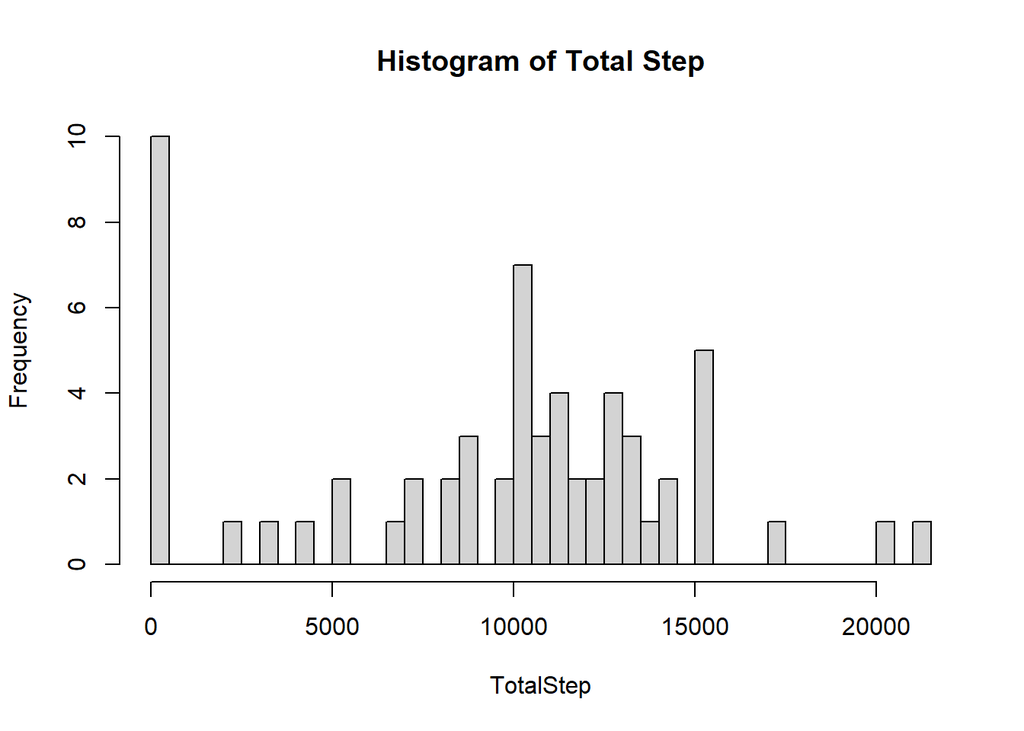

```r
MonitorData$date<- as.factor(MonitorData$date)
x1<- data.frame(sapply(split(MonitorData,MonitorData$date),function(x){sum(x[,1],na.rm = TRUE)}))
TotalStep<- data.frame(Date=row.names(x1),TotalStep=x1[,1])
hist(TotalStep$TotalStep,breaks=61,xlab = "TotalStep",main="Histogram of Total Step")
```

##Mean and Median of steps

Now I’m going to calculate the mean and median of Total Steps per day

```r
data.frame(Mean=mean(TotalStep$TotalStep),Median=median(TotalStep$TotalStep),row.names = NULL)
```

```
##      Mean Median
## 1 9354.23  10395
```

##Time series plotting

Now I will make a data frame named Average Step consisting the columns of Interval and Average Step.  
For that I will factorize *interval* column and then make it.  
And going to make a plot of time series.

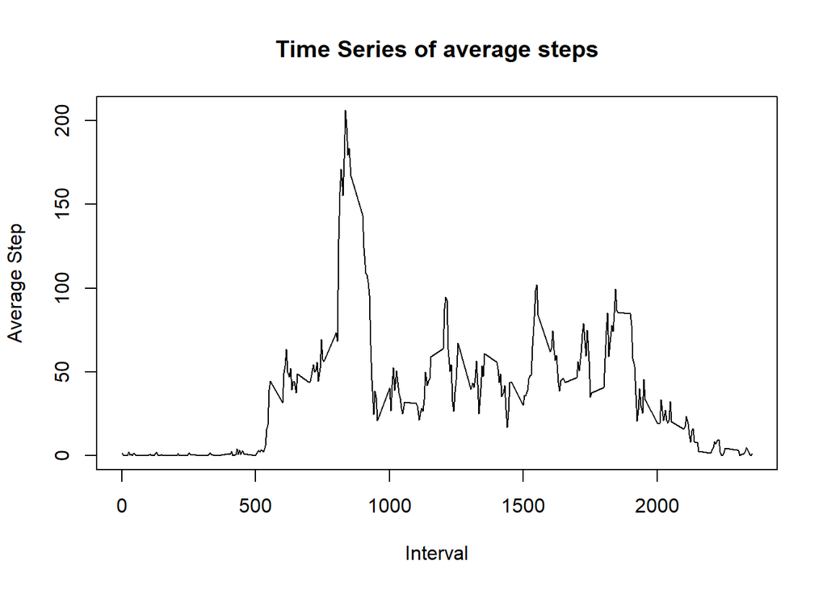

```r
MonitorData$interval<- as.factor(MonitorData$interval)
x2<- data.frame(sapply(split(MonitorData,MonitorData$interval),function(x){mean(x[,1],na.rm = TRUE)}))
AverageStep<- data.frame(Interval=row.names(x2),AverageStep=x2[,1])
plot(AverageStep$Interval,AverageStep$AverageStep,main = "Time Series of average steps",xlab = "Interval",ylab="Average Step",type = "l")
```

##Maximum Step

```r
max(AverageStep$AverageStep,na.rm = TRUE)
```

```
## [1] 206.1698
```

- Now firstly I’m going to make a intermediate variable which will be a logical  
  vector having no NA
- Then will subset the dataframe.

```r
x3<- !is.na(MonitorData$steps)
MonitorDatawithoutNA<- MonitorData[x3,]
```

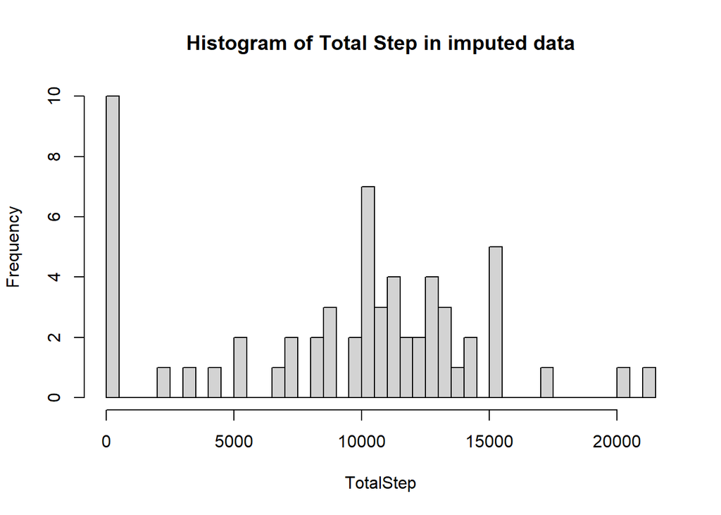

```r
MonitorDatawithoutNA$date<- as.factor(MonitorDatawithoutNA$date)
x4<- data.frame(sapply(split(MonitorDatawithoutNA,MonitorDatawithoutNA$date),function(x){sum(x[,1],na.rm = TRUE)}))
TotalStep2<- data.frame(Date=row.names(x4),TotalStep=x4[,1])
hist(TotalStep2$TotalStep,breaks=61,xlab = "TotalStep",main="Histogram of Total Step in imputed data")
```

```r
data.frame(Mean=mean(TotalStep2$TotalStep),Median=median(TotalStep2$TotalStep),row.names = NULL)
```

```
##      Mean Median
## 1 9354.23  10395
```

It doesn’t differ either.

##Adding Variable

Now I,m going to add a new variable in dataset which will contain a variable if it is a weekdays or not.

```r
library(lubridate)
MonitorDatawithoutNA$date<- ymd(MonitorDatawithoutNA$date)
MonitorDatawithoutNA$status<- wday(MonitorDatawithoutNA$date,label = FALSE)
MonitorDatawithoutNA$status<- MonitorDatawithoutNA$status %in% c(1,2)
MonitorDatawithoutNA$status<- sub("FALSE","WEEKDAYS",MonitorDatawithoutNA$status)
MonitorDatawithoutNA$status<- sub("TRUE","WEEKEND",MonitorDatawithoutNA$status)
```

Firstly I will make a dataset with averagestep.

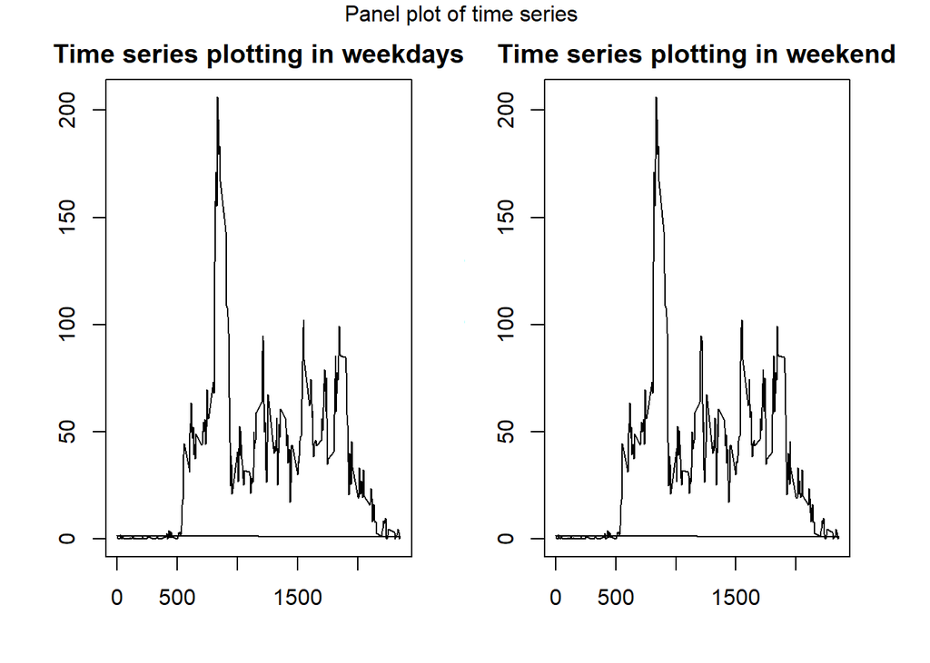

```r
MonitorDatawithoutNA$interval<- as.factor(MonitorDatawithoutNA$interval)
x5<- data.frame(sapply(split(MonitorDatawithoutNA,MonitorDatawithoutNA$interval),function(x){mean(x[,1],na.rm = TRUE)}))
AverageStep2<- data.frame(Interval=row.names(x5),AverageStep=x5[,1],status=MonitorDatawithoutNA$status)
AverageStep2<- split(AverageStep2,AverageStep2$status)
par(mfrow=c(1,2),mar=c(3,3,2,2),oma=c(1,1,1,1))
plot(AverageStep2$WEEKDAYS$Interval,AverageStep2$WEEKDAYS$AverageStep,xlab = "Interval",ylab = "Average Step",main = "Time series plotting in weekdays",type = "l")
plot(AverageStep2$WEEKEND$Interval,AverageStep2$WEEKEND$AverageStep,xlab = "Interval",ylab = "Average Step",main = "Time series plotting in weekend",type = "l")
mtext("Panel plot of time series ",outer=TRUE)
```